# Introducción general al uso de R Clase práctica 03

Autor/a

Afiliación

Ignacio Minoli  
`minolicnp@gmail.com`

Observatorio de Biodiversidad del Bosque Atlántico (OBBA) Instituto de Biología Subtropical (IBS) - Unidad Ejecutora del CONICET - UNaM

Fecha de publicación

21 de agosto de 2024

# 1 Utilización de Pipes

La implementación de los *pipes* fue revolucionario para el lenguaje R, ya que reduce el número de objetos en la sesión y disminuye el uso de recursos en el workspace. Actualmente se utilizan los pipes para casi todos los comandos a realizar, pero su uso más frecuente se da para:

- Fines estadísticos:
  - Subsets
  - Exploración de objetos
  - Estadísticas de resumen
- Manipulación de datos:
  - Reordenar set de datos
  - Cambio de formatos
  - Creación de nuevas variables
- Unión de data frames o tibbles:
  - Filas
  - Columnas
  - Id
  - Direccionalmente

# 2 Diferentes tipos de pipes

Está el pipe de R base **|>** que se implementó años después de la aparición del pipe **%>%**. No es ampliamente usado, pero puede encontrarse en algunos tutoriales o scripts.

```r
# Llamo a las librerias
library(palmerpenguins)
library(ggplot2)
library(dplyr)
glimpse(penguins)
```

```
Rows: 344
Columns: 8
$ species           <fct> Adelie, Adelie, Adelie, Adelie, Adelie, Adelie, Adel…
$ island            <fct> Torgersen, Torgersen, Torgersen, Torgersen, Torgerse…
$ bill_length_mm    <dbl> 39.1, 39.5, 40.3, NA, 36.7, 39.3, 38.9, 39.2, 34.1, …
$ bill_depth_mm     <dbl> 18.7, 17.4, 18.0, NA, 19.3, 20.6, 17.8, 19.6, 18.1, …
$ flipper_length_mm <int> 181, 186, 195, NA, 193, 190, 181, 195, 193, 190, 186…
$ body_mass_g       <int> 3750, 3800, 3250, NA, 3450, 3650, 3625, 4675, 3475, …
$ sex               <fct> male, female, female, NA, female, male, female, male…
$ year              <int> 2007, 2007, 2007, 2007, 2007, 2007, 2007, 2007, 2007…
```

```r
penguins |> # set de datos
  filter(sex == "male") |> # filtra sólo los machos
  filter(body_mass_g > 3550) |> # filtra sólo condicional para masa coporal
  qplot(x = flipper_length_mm, y = body_mass_g, geom=c("point"),
        color = factor(species), data = penguins) + # es el plot en sí mismo
  theme(legend.position = c(0.25, 0.8)) # es solo la leyenda
```

```
Error in `geom_point()`:
! `mapping` must be created by `aes()`.
```

¿Da error? El pipe del R base no funciona exactamente igual que el pipe **%>%**, por lo que debemos primero crear el subset de datos para hacer el plot que quiero obtener más arriba.

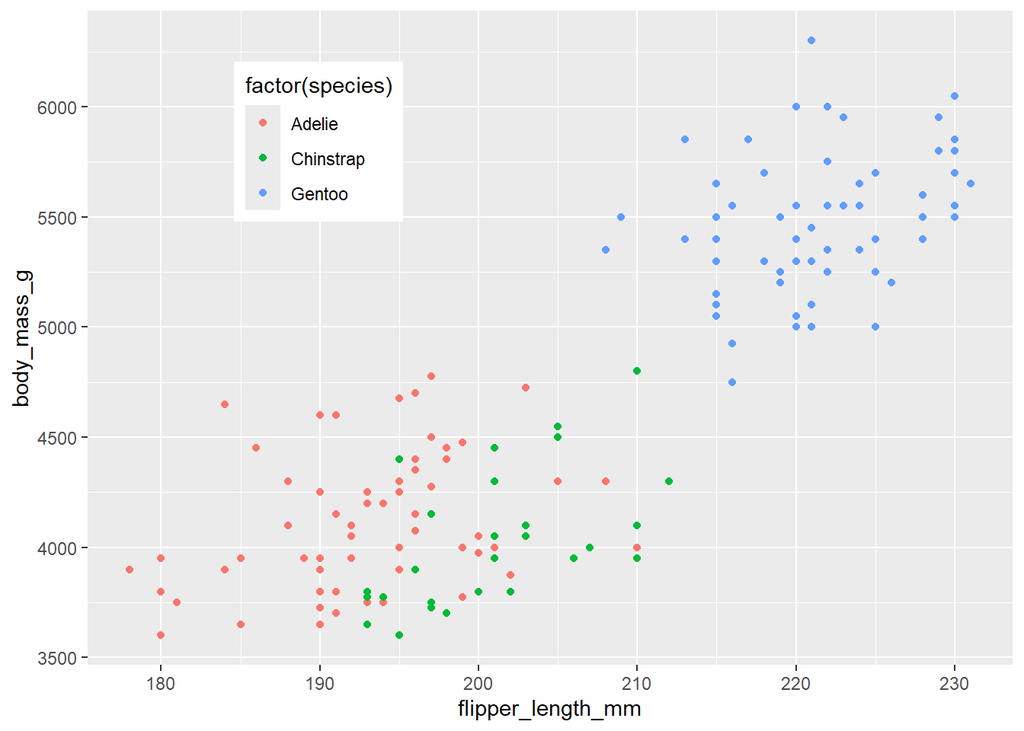

```r
new_penguins <- penguins |> # set de datos
  filter(sex == "male") |> # filtra sólo los machos
  filter(body_mass_g > 3550) # filtra condicional para masa coporal

qplot(x = flipper_length_mm,
      y = body_mass_g,
      geom=c("point"),
      color = factor(species),
      data = new_penguins) + # es el plot en sí mismo
  theme(legend.position = c(0.25, 0.8)) # es solo la leyenda
```

Por último, así quedaría más sintético con el pipe **%>%**. Es el tipo de pipe que usaremos de aquí en adelante y en RStudio se emplea con el shortcut CTRL+SHIFT+m.

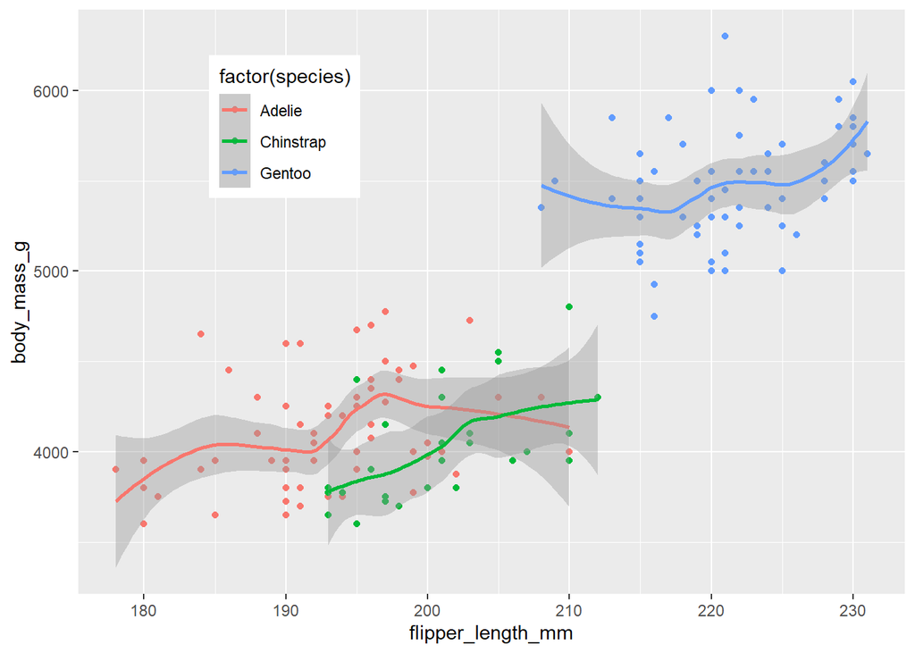

```r
penguins %>% # set de datos
  filter(sex == "male") %>% # filtra sólo los machos
  filter(body_mass_g > 3550) %>% # filtra condicional para masa coporal
  qplot(x = flipper_length_mm,
        y = body_mass_g,
        geom=c("point"),
        color = factor(species), data = .) + # es el plot en sí mismo
  theme(legend.position = c(0.25, 0.8)) + # leyenda
  geom_smooth(formula = y ~ x, method = "loess")
```

# 3 Fines estadísticos

## 3.1 Subsets sin pipes

```r
# Selección variables con R base.

# Agrego el set de datos
attach(mtcars)
# Exploro la estructura
str(mtcars)
```

```
'data.frame':   32 obs. of  11 variables:
 $ mpg : num  21 21 22.8 21.4 18.7 18.1 14.3 24.4 22.8 19.2 ...
 $ cyl : num  6 6 4 6 8 6 8 4 4 6 ...
 $ disp: num  160 160 108 258 360 ...
 $ hp  : num  110 110 93 110 175 105 245 62 95 123 ...
 $ drat: num  3.9 3.9 3.85 3.08 3.15 2.76 3.21 3.69 3.92 3.92 ...
 $ wt  : num  2.62 2.88 2.32 3.21 3.44 ...
 $ qsec: num  16.5 17 18.6 19.4 17 ...
 $ vs  : num  0 0 1 1 0 1 0 1 1 1 ...
 $ am  : num  1 1 1 0 0 0 0 0 0 0 ...
 $ gear: num  4 4 4 3 3 3 3 4 4 4 ...
 $ carb: num  4 4 1 1 2 1 4 2 2 4 ...
```

```r
# Hago el subset de variables indexado por nombres
selec_data <- mtcars[c("disp", "hp", "gear")]

# Visualizo el resultado
head(selec_data, 4)
```

```
               disp  hp gear
Mazda RX4       160 110    4
Mazda RX4 Wag   160 110    4
Datsun 710      108  93    4
Hornet 4 Drive  258 110    3
```

## 3.2 Subsets con pipes

Primero debo explorar el objeto en su estructura y valores para poder hacer los subsets.

```r
# Exploración del set de datos
iris %>%
  glimpse()
```

```
Rows: 150
Columns: 5
$ Sepal.Length <dbl> 5.1, 4.9, 4.7, 4.6, 5.0, 5.4, 4.6, 5.0, 4.4, 4.9, 5.4, 4.…
$ Sepal.Width  <dbl> 3.5, 3.0, 3.2, 3.1, 3.6, 3.9, 3.4, 3.4, 2.9, 3.1, 3.7, 3.…
$ Petal.Length <dbl> 1.4, 1.4, 1.3, 1.5, 1.4, 1.7, 1.4, 1.5, 1.4, 1.5, 1.5, 1.…
$ Petal.Width  <dbl> 0.2, 0.2, 0.2, 0.2, 0.2, 0.4, 0.3, 0.2, 0.2, 0.1, 0.2, 0.…
$ Species      <fct> setosa, setosa, setosa, setosa, setosa, setosa, setosa, s…
```

Previa exploración del objeto, ya estamos en condiciones de hacer nuevos objetos con subsets. Dentro de la familia **tidyverse** hay dos funciones esenciales: **filter()** para hacer subset de **filas** y la función **select()** para hacer subsets de **columnas** o **variables**.

```r
# Creación del subset de ciertas filas
df_virginica_filas <- iris %>%
  filter(Species == "virginica")

# Exploro el subset creado
head(df_virginica_filas, 4)
```

```
  Sepal.Length Sepal.Width Petal.Length Petal.Width   Species
1          6.3         3.3          6.0         2.5 virginica
2          5.8         2.7          5.1         1.9 virginica
3          7.1         3.0          5.9         2.1 virginica
4          6.3         2.9          5.6         1.8 virginica
```

```r
# Creación del subset de ciertas columnas
df_virginica_cols <- iris %>%
  select(Species, Petal.Width)

# Exploro el subset creado
head(df_virginica_cols, 4)
```

```
  Species Petal.Width
1  setosa         0.2
2  setosa         0.2
3  setosa         0.2
4  setosa         0.2
```

```r
# Ejercicio 03.1 correr este comando
¿Qué tipo de objetos son iris y df_virginica_filas?
```

Puedo hacer filtros con **group_by()** y sin **group_by()**.

```r
# Subset de filas con R familia tidyverse SIN group_by().
starwars %>%
filter(mass > mean(mass, na.rm = TRUE)) %>%
print(n=3)
```

```
# A tibble: 10 × 14
  name      height  mass hair_color skin_color eye_color birth_year sex   gender
  <chr>      <int> <dbl> <chr>      <chr>      <chr>          <dbl> <chr> <chr>
1 Darth Va…    202   136 none       white      yellow          41.9 male  mascu…
2 Owen Lars    178   120 brown, gr… light      blue            52   male  mascu…
3 Chewbacca    228   112 brown      unknown    blue           200   male  mascu…
# ℹ 7 more rows
# ℹ 5 more variables: homeworld <chr>, species <chr>, films <list>,
#   vehicles <list>, starships <list>
```

```r
# Ejercicio 03.2 correr este comando
1- Con el data set starwars, usar la función table() para explorar los tipos de
ojos de la variable "eye_color".
2- Crear un nuevo objeto a partir del data set starwars, con un filtro
group_by() con la variable "eye_color" y que la variable "mass" sea mayor que
la media.
3- Imprimir todos los objetos en la consola.
```

Puedo hacer subsets de columnas o variables de un tibble con la función **select()**.

```r
# Ejercicio 03.3 correr este comando
1- Correr help(select), correr los ejemplos de uso y seleccionar variables de
un data set.
2- Imprimir todos los objetos en la consola.
```

Para hacer subsets hay que recordar estos operadores y asistentes:

- Seleccionar variables con operadores:
  - **:** para seleccionar un rango consecutivo de variables.
  - **!** para seleccionar un set complementario de variables.
  - **&** y **|** para seleccionar intersección o unión de un set de 2 variables.
  - **c()** para combinar selecciones.
- Se complementa con asistentes:
  - **everything()**: para todas las variables (específico de columnas).
  - **last_col()**: selecciona la última variables (específico de columnas).
  - **starts_with()**: comienza con un prefijo (match de patrones en los nombres).
  - **ends_with()**: termina con un sufijo (match de patrones en los nombres).
  - **contains()**: contiene un string literal (match de patrones en los nombres).
  - **matches()**: match con una expresion regular (match de patrones en los nombres).
  - **num_range()**: match en un rango numérico (match de patrones en los nombres).

Los operadores base combinados con los asistentes de la familia tidyverse revolucionaron la manera de consultar un set de datos. Por ejemplo:

```r
# Veo el data frame original
head(iris, 5)
```

```
  Sepal.Length Sepal.Width Petal.Length Petal.Width Species
1          5.1         3.5          1.4         0.2  setosa
2          4.9         3.0          1.4         0.2  setosa
3          4.7         3.2          1.3         0.2  setosa
4          4.6         3.1          1.5         0.2  setosa
5          5.0         3.6          1.4         0.2  setosa
```

```r
# Utilizo operadores y asistentes
iris %>%
  select(starts_with("Petal") | ends_with("Width")) %>%
  head(5)
```

```
  Petal.Length Petal.Width Sepal.Width
1          1.4         0.2         3.5
2          1.4         0.2         3.0
3          1.3         0.2         3.2
4          1.5         0.2         3.1
5          1.4         0.2         3.6
```

## 3.3 Estadísticas de resumen

Podemos además, hacer medidas de resumen con la función R base **summary()** o **summarize()** que es de la familia tidyverse y seleccionar que funciones implementar.

```r
iris %>%
  summary() # es una función de R base
```

```
  Sepal.Length    Sepal.Width     Petal.Length    Petal.Width
 Min.   :4.300   Min.   :2.000   Min.   :1.000   Min.   :0.100
 1st Qu.:5.100   1st Qu.:2.800   1st Qu.:1.600   1st Qu.:0.300
 Median :5.800   Median :3.000   Median :4.350   Median :1.300
 Mean   :5.843   Mean   :3.057   Mean   :3.758   Mean   :1.199
 3rd Qu.:6.400   3rd Qu.:3.300   3rd Qu.:5.100   3rd Qu.:1.800
 Max.   :7.900   Max.   :4.400   Max.   :6.900   Max.   :2.500
       Species
 setosa    :50
 versicolor:50
 virginica :50
```

Uso la función **group_by()** que me permite definir grupos por variables o columnas y luego aplicar en estos grupos cálculos o manipulación de los datos.

```r
iris %>%
  group_by(Species) %>%
  summarize(
    mean_size = mean(Petal.Length,
                     na.rm = TRUE
                     ),
    n()
    )
```

```
# A tibble: 3 × 3
  Species    mean_size `n()`
  <fct>          <dbl> <int>
1 setosa          1.46    50
2 versicolor      4.26    50
3 virginica       5.55    50
```

```r
# Ejercicio 03.4 correr este comando
1- Hacer un subset de data(penguins) creando un nuevo objeto con penguins por especie, creando nuevas variables con las funciones min(), max(), mean() y sd() para una sola variable.
```

# 4 Manipulación de datos

## 4.1 Reordenamiento

El reordenamiento se suele utilizar para visualizar ciertas tendencias, con la intención de hacer subsets utilizando la posición, o crear un plot con cierta visualización de los datos en modo ascendente o descendente.

```r
# Agrego un data frame
attach(mtcars)
# R base.
# Orden ascendente a partir de la variable mpg
new_mtcars <- mtcars[order(mpg),]
head(mtcars, 3)
```

```
               mpg cyl disp  hp drat    wt  qsec vs am gear carb
Mazda RX4     21.0   6  160 110 3.90 2.620 16.46  0  1    4    4
Mazda RX4 Wag 21.0   6  160 110 3.90 2.875 17.02  0  1    4    4
Datsun 710    22.8   4  108  93 3.85 2.320 18.61  1  1    4    1
```

```r
head(new_mtcars, 3)
```

```
                     mpg cyl disp  hp drat    wt  qsec vs am gear carb
Cadillac Fleetwood  10.4   8  472 205 2.93 5.250 17.98  0  0    3    4
Lincoln Continental 10.4   8  460 215 3.00 5.424 17.82  0  0    3    4
Camaro Z28          13.3   8  350 245 3.73 3.840 15.41  0  0    3    4
```

```r
library(dplyr)

# R dplyr o familia tidyverse.
# Orden ascendente a partir de la variable mpg
new_mtcars <- mtcars %>%
arrange(mpg)
head(mtcars, 3)
```

```
               mpg cyl disp  hp drat    wt  qsec vs am gear carb
Mazda RX4     21.0   6  160 110 3.90 2.620 16.46  0  1    4    4
Mazda RX4 Wag 21.0   6  160 110 3.90 2.875 17.02  0  1    4    4
Datsun 710    22.8   4  108  93 3.85 2.320 18.61  1  1    4    1
```

```r
head(new_mtcars, 3)
```

```
                     mpg cyl disp  hp drat    wt  qsec vs am gear carb
Cadillac Fleetwood  10.4   8  472 205 2.93 5.250 17.98  0  0    3    4
Lincoln Continental 10.4   8  460 215 3.00 5.424 17.82  0  0    3    4
Camaro Z28          13.3   8  350 245 3.73 3.840 15.41  0  0    3    4
```

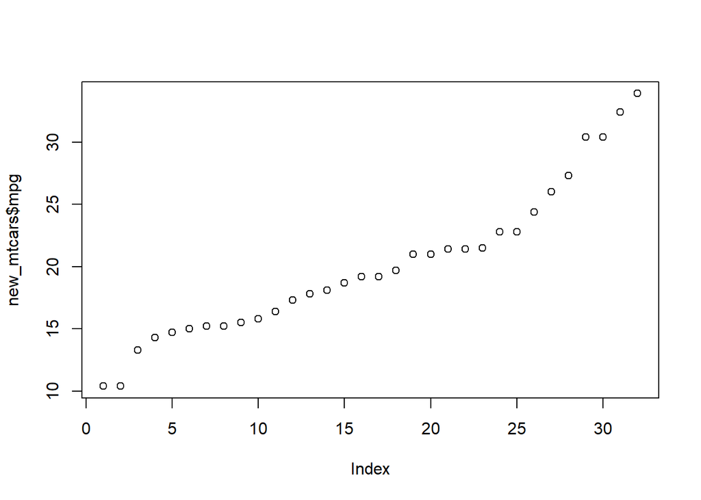

```r
# Como es la visualización?
plot(new_mtcars$mpg)
```

```r
# R dplyr.
# Orden descendente a partir de la variable mpg
new_mtcars_inv <- mtcars %>%
arrange(desc(mpg))
head(mtcars, 3)
```

```
               mpg cyl disp  hp drat    wt  qsec vs am gear carb
Mazda RX4     21.0   6  160 110 3.90 2.620 16.46  0  1    4    4
Mazda RX4 Wag 21.0   6  160 110 3.90 2.875 17.02  0  1    4    4
Datsun 710    22.8   4  108  93 3.85 2.320 18.61  1  1    4    1
```

```r
head(new_mtcars_inv, 3)
```

```
                mpg cyl disp hp drat    wt  qsec vs am gear carb
Toyota Corolla 33.9   4 71.1 65 4.22 1.835 19.90  1  1    4    1
Fiat 128       32.4   4 78.7 66 4.08 2.200 19.47  1  1    4    1
Honda Civic    30.4   4 75.7 52 4.93 1.615 18.52  1  1    4    2
```

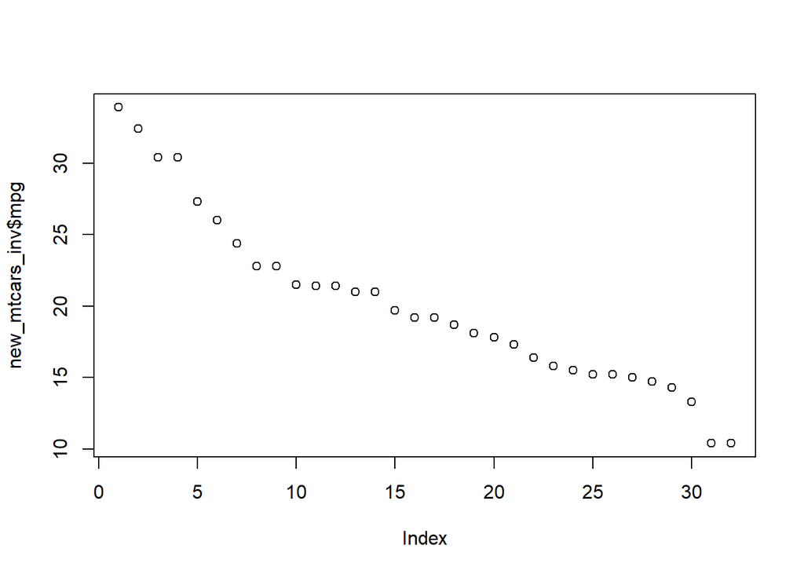

```r
# Como es la visualización?
plot(new_mtcars_inv$mpg)
```

## 4.2 Cambio de formatos

Es necesario poder manejar los cambios de formatos o clases de manera efectiva, porque hay algunas funciones de paquetes que funcionan con un input de determinadas clases o formatos.

Ejemplos con R base

```r
df <- data.frame(x1 = LETTERS[5:10],
                 x2 = as.character(5:10),
                 x3 = as.character(seq(0, 1, 0.2))
                 )
df
```

```
  x1 x2  x3
1  E  5   0
2  F  6 0.2
3  G  7 0.4
4  H  8 0.6
5  I  9 0.8
6  J 10   1
```

```r
sapply(df, class)
```

```
         x1          x2          x3
"character" "character" "character"
```

```r
# Usando la función de R base type.convert()
df <- data.frame(x1 = LETTERS[5:10],
                 x2 = as.character(5:10),
                 x3 = as.character(seq(0, 1, 0.2))
                 )
df_new <- type.convert(df, as.is = TRUE)
df_new
```

```
  x1 x2  x3
1  E  5 0.0
2  F  6 0.2
3  G  7 0.4
4  H  8 0.6
5  I  9 0.8
6  J 10 1.0
```

```r
sapply(df_new, class)
```

```
         x1          x2          x3
"character"   "integer"   "numeric"
```

Utilizando los comandos **help()** y **showMethods(“coerce”)** podemos ver los cambios de clases posibles. Además, están los posibles cambios de clases de objetos propios definidos en el contexto de otros paquetes (googlear o ver con ayuda en R por ejemplo **??st_as_sf**).

## 4.3 Creación de nuevas variables

Gracias al manejo previo de los vectores y las operaciones posibles entre ellos, al asignar una nueva columna al data frame ya estoy creando una nueva variable. Con R base:

```r
# En R base

# Creo 3 vectores
hospital <- c("Garrahan", "Perrando")
pacientes <- c(150, 350)
cost_indv <- c(3.1, 2.5)

# Junto esos vectores y creo un data frame con la función data.frame()
df <- data.frame(hospital, pacientes, cost_indv)

# Creo una nueva variable
df$tot_cost <- df$pacientes * df$cost_indv
df$tot_cost
```

```
[1] 465 875
```

```r
# Exploro el objeto
df
```

```
  hospital pacientes cost_indv tot_cost
1 Garrahan       150       3.1      465
2 Perrando       350       2.5      875
```

Si utilizo la familia tidyverse, puedo crear nuevas variables con la función **mutate()**.

```r
# Con familia tidyverse
library(dplyr)

# Creo el tibble
df <- tibble(hospital = c("Garrahan", "Perrando"),
             pacientes = c(150, 350),
             cost_indv = c(3.1, 2.5)
             )

# Creo nuevas variables
df_m <- df %>% mutate(
  tot_cost = pacientes * cost_indv,
  tot_cost_3y = tot_cost * 3,
  subsidio = case_when(tot_cost_3y > 1500 ~ "Si Corresponde",
                       tot_cost_3y < 1500 ~ "No Corresponde"
                       )
)

# Exploro el objeto
df_m
```

```
# A tibble: 2 × 6
  hospital pacientes cost_indv tot_cost tot_cost_3y subsidio
  <chr>        <dbl>     <dbl>    <dbl>       <dbl> <chr>
1 Garrahan       150       3.1      465        1395 No Corresponde
2 Perrando       350       2.5      875        2625 Si Corresponde
```

# 5 Unión de data frames o tibbles

Es otra de las acciones que normalmente se realizan en R, ya que un mismo set de datos suele ser analizado con diferentes test estadísticos o métricas y luego quiero reunir toda la información.

Con R base, están cubiertas las operaciones más básicas para este tipo de uniones en data frames: **rbind()**, **cbind()**, **merge()**, **join()**.

## 5.1 Filas

Ejemplo de unión por filas:

```r
# Creo dos vectores
Tasa_Desemp_B <- c(10, 15, 22)
Ingr_Fam <- c(100, 150, 300)

# Uno las filas del data frame
df_comp <- rbind(Tasa_Desemp_B, Ingr_Fam)

# Exploro el objeto
str(df_comp)
```

```
 num [1:2, 1:3] 10 100 15 150 22 300
 - attr(*, "dimnames")=List of 2
  ..$ : chr [1:2] "Tasa_Desemp_B" "Ingr_Fam"
  ..$ : NULL
```

```r
df_comp
```

```
              [,1] [,2] [,3]
Tasa_Desemp_B   10   15   22
Ingr_Fam       100  150  300
```

```r
# Ejercicio 03.5 correr este comando
1- Luego de correr el ejemplo anterior ¿Qué clase de objeto es?.
2- Transformarlo en data frame o tibble creando un nuevo objeto.
3- Ver help(names) y ver de cambiar el nombre de las variables.
4- Imprimir todos los objetos en consola.
```

## 5.2 Columnas

Ejemplos de unión por columnas:

```r
# Creo dos vectores
Tasa_Desemp_A <- c(6.6, 6.7, 8.2)
Camb_Urb <- c(0.2, 0.1, 0.5)

# Los uno por columnas
df_laboral <- cbind(Tasa_Desemp_A, Camb_Urb)

# Veo el objeto en la consola
df_laboral
```

```
     Tasa_Desemp_A Camb_Urb
[1,]           6.6      0.2
[2,]           6.7      0.1
[3,]           8.2      0.5
```

```r
# Ejercicio 03.6 correr este comando
1- Luego de correr el ejemplo anterior ¿Qué clase de objeto es?.
2- Transformarlo en data frame o tibble creando un nuevo objeto.
3- Imprimir todos los objetos en consola.
```

Con las funciones de la familia tidyverse se puede concretar esta acción con mejoras sobre el R base. Estas funciones son **bind_rows()**, **bind_cols()**, **join()**. Ver estas operaciones como funciona el R base *versus* tidyverse:

```r
# Creo dos data frames
a <- data.frame(a = 1:2, b = 3:4, c = 5:6)
b <- data.frame(a = 7:8, b = 2:3, c = 3:4, d = 8:9)

# Función de unión de filas con R Base
rbind(a, b)
```

```
Error in rbind(deparse.level, ...): numbers of columns of arguments do not match
```

¿Qué pasó? ¿Qué error arroja la consola?

```r
# Ahora intento con la función de unión de filas de la familia tidyverse
bind_rows(a, b)
```

```
  a b c  d
1 1 3 5 NA
2 2 4 6 NA
3 7 2 3  8
4 8 3 4  9
```

¿Y ahora? ¿Que observan?

## 5.3 Id

Este tipo de unión de data frames tiene su función en el R base, pero ante la diversidad de argumentos (opciones para el usuario) de las funciones de la familia tidyverse, actualmente se emplean casi siempre estas nuevas funciones.

```r
# Puedo unir los dos data frame por filas con tidyverse

# Comparar lo observado para estos objetos
a
```

```
  a b c
1 1 3 5
2 2 4 6
```

```r
b
```

```
  a b c d
1 7 2 3 8
2 8 3 4 9
```

```r
# Utilizando el argumento id puedo dejar diferenciados los data frame unidos.
# Es decir, me informa de que dataframe o tibble provienen esas filas!
bind_rows(list(a, b), .id = "id")
```

```
  id a b c  d
1  1 1 3 5 NA
2  1 2 4 6 NA
3  2 7 2 3  8
4  2 8 3 4  9
```

## 5.4 Direccionalmente

Son muy utilizadas este tipo de operaciones entre data frames o tibbles. Tenemos estas opciones:

Llamando el paquete dplyr:

- inner_join(): incluye todas las filas de x and y
- left_join(): incluye todas las filas de x
- right_join(): incluye todas las filas de y
- full_join(): incluye todas las filas de x or y
- semi_join(): devuelve todas las filas de x que SI coincidan en y
- anti_join(): devuelve todas las filas de x que NO coincidan en y

Ejemplos

```r
# Dos tibbles
band_members
```

```
# A tibble: 3 × 2
  name  band
  <chr> <chr>
1 Mick  Stones
2 John  Beatles
3 Paul  Beatles
```

```r
band_instruments
```

```
# A tibble: 3 × 2
  name  plays
  <chr> <chr>
1 John  guitar
2 Paul  bass
3 Keith guitar
```

```r
# Ejemplo de inner_join
# Devuelve todas las filas del 1er tibble que estan en el 2do tibble, pero lo que no se puede unir no se mantiene, son observaciones que se pierden.
band_members %>% inner_join(band_instruments)
```

```
# A tibble: 2 × 3
  name  band    plays
  <chr> <chr>   <chr>
1 John  Beatles guitar
2 Paul  Beatles bass
```

```r
# Dos tibbles
band_members
```

```
# A tibble: 3 × 2
  name  band
  <chr> <chr>
1 Mick  Stones
2 John  Beatles
3 Paul  Beatles
```

```r
band_instruments
```

```
# A tibble: 3 × 2
  name  plays
  <chr> <chr>
1 John  guitar
2 Paul  bass
3 Keith guitar
```

```r
# Ejemplo de left_join
# Devuelve todas las filas del 1er tibble
band_members %>% left_join(band_instruments)
```

```
# A tibble: 3 × 3
  name  band    plays
  <chr> <chr>   <chr>
1 Mick  Stones  <NA>
2 John  Beatles guitar
3 Paul  Beatles bass
```

```r
# Dos tibbles
band_members
```

```
# A tibble: 3 × 2
  name  band
  <chr> <chr>
1 Mick  Stones
2 John  Beatles
3 Paul  Beatles
```

```r
band_instruments
```

```
# A tibble: 3 × 2
  name  plays
  <chr> <chr>
1 John  guitar
2 Paul  bass
3 Keith guitar
```

```r
# Ejemplo de right_join
# Devuelve todas las filas del 2do tibble
band_members %>% right_join(band_instruments)
```

```
# A tibble: 3 × 3
  name  band    plays
  <chr> <chr>   <chr>
1 John  Beatles guitar
2 Paul  Beatles bass
3 Keith <NA>    guitar
```

```r
# Dos tibbles
band_members
```

```
# A tibble: 3 × 2
  name  band
  <chr> <chr>
1 Mick  Stones
2 John  Beatles
3 Paul  Beatles
```

```r
band_instruments
```

```
# A tibble: 3 × 2
  name  plays
  <chr> <chr>
1 John  guitar
2 Paul  bass
3 Keith guitar
```

```r
# Ejemplo de full_join
# Devuelve todas las filas de los 2 tibbles
band_members %>% full_join(band_instruments)
```

```
# A tibble: 4 × 3
  name  band    plays
  <chr> <chr>   <chr>
1 Mick  Stones  <NA>
2 John  Beatles guitar
3 Paul  Beatles bass
4 Keith <NA>    guitar
```

```r
# Si quiero remover ese mensaje o especificar que campo será el operador del join
band_members %>% inner_join(band_instruments, by = "name")
```

```
# A tibble: 2 × 3
  name  band    plays
  <chr> <chr>   <chr>
1 John  Beatles guitar
2 Paul  Beatles bass
```

```r
# Dos tibbles
band_members
```

```
# A tibble: 3 × 2
  name  band
  <chr> <chr>
1 Mick  Stones
2 John  Beatles
3 Paul  Beatles
```

```r
band_instruments
```

```
# A tibble: 3 × 2
  name  plays
  <chr> <chr>
1 John  guitar
2 Paul  bass
3 Keith guitar
```

```r
# Ejemplo de semi_join. Si especifico by = x, puedo excluir columnas del 2 dataframe.
band_members %>% semi_join(band_instruments)
```

```
# A tibble: 2 × 2
  name  band
  <chr> <chr>
1 John  Beatles
2 Paul  Beatles
```

```r
# Dos tibbles
band_members
```

```
# A tibble: 3 × 2
  name  band
  <chr> <chr>
1 Mick  Stones
2 John  Beatles
3 Paul  Beatles
```

```r
band_instruments
```

```
# A tibble: 3 × 2
  name  plays
  <chr> <chr>
1 John  guitar
2 Paul  bass
3 Keith guitar
```

```r
# Ejemplo de anti_join
# Devuelve todas las filas del 1er dataframe que NO coinciden con el 2do dataframe
band_members %>% anti_join(band_instruments)
```

```
# A tibble: 1 × 2
  name  band
  <chr> <chr>
1 Mick  Stones
```

```r
# Ejercicio 03.7 correr este comando
1- Abrir en la sesion los archivos csv "df1_tp3.csv" y "df2_tp3.csv" de estas url y asignarlos a dos objetos:
https://raw.githubusercontent.com/iminoli/EcoInformatics/master/pdf/Curso.R.2024/Practicos/df1_tp3.csv
https://raw.githubusercontent.com/iminoli/EcoInformatics/master/pdf/Curso.R.2024/Practicos/df2_tp3.csv

2- Implementar un left_join() usando el acronimo para unir esos tibbles o dataframes.

3- Explorar el objeto, entender que ocurrió con las columnas. Diferenciar entre las columnas del nuevo objeto de cual set de datos proviene cada una de ellas, cambiarles el nombre y asignarlas a un objeto final.

4- Con ese objeto final, guardarlo como un nuevo .csv

# OPCIONAL
Seleccionar que variables quiero quedarme y renombralas nuevamente. Luego guardar otra version del .csv con ese set de variables seleccionadas.
```